# Using ants as bioindicators in land management: simplifying assessment of ant community responses - Andersen - 2002 - Journal of Applied Ecology - Wiley Online Library

[Journal of Applied Ecology](https://besjournals.onlinelibrary.wiley.com/journal/13652664)

[Volume 39, Issue 1](https://besjournals.onlinelibrary.wiley.com/toc/13652664/2002/39/1)

[figure not shown]

Free Access

# Using ants as bioindicators in land management: simplifying assessment of ant community responses

[Alan N. Andersen](https://besjournals.onlinelibrary.wiley.com/action/doSearch?ContribAuthorStored=Andersen%2C+Alan+N)

Alan Andersen, Tropical Savannas Cooperative Research Centre, Division of Sustainable Ecosystems, CSIRO Tropical Ecosystems Research Centre, PMB 44 Winnellie, NT 0822, Australia (e‐mail ).

[Benjamin D. Hoffmann](https://besjournals.onlinelibrary.wiley.com/action/doSearch?ContribAuthorStored=Hoffmann%2C+Benjamin+D)

[Warren J. Müller](https://besjournals.onlinelibrary.wiley.com/action/doSearch?ContribAuthorStored=M%C3%BCller%2C+Warren+J)

[Anthony D. Griffiths](https://besjournals.onlinelibrary.wiley.com/action/doSearch?ContribAuthorStored=Griffiths%2C+Anthony+D)

First published: 26 June 2002

https://doi.org/10.1046/j.1365-2664.2002.00704.x

Citations: 138

## Summary

- 1

  The indicator qualities of terrestrial invertebrates are widely recognized in the context of detecting ecological change associated with human land‐use. However, the use of terrestrial invertebrates as bioindicators remains more a topic of scientific discourse than a part of land‐management practice, largely because their inordinate numbers, taxonomic challenges and general unfamiliarity make invertebrates too intimidating for most land‐management agencies. Terrestrial invertebrates will not be widely adopted as bioindicators in land management until simple and efficient protocols have been developed that meet the needs of land managers.
- 2

  In Australia, ants are one group of terrestrial insects that has been commonly adopted as bioindicators in land management, and this study examined the reliability of a simplified ant assessment protocol designed to be within the capacity of a wide range of land managers.
- 3

  Ants had previously been surveyed intensively as part of a comprehensive assessment of biodiversity responses to SO<sub>2</sub> emissions from a large copper and lead smelter at Mt Isa in the Australian semi‐arid tropics. This intensive ant survey yielded 174 species from 24 genera, and revealed seven key patterns of ant community structure and composition in relation to habitat and SO<sub>2</sub> levels.
- 4

  We tested the extent to which a greatly simplified ant assessment was able to reproduce these results. Our simplified assessment was based on ant ‘bycatch’ from bucket‐sized (20‐litre) pitfall traps used to sample vertebrates as part of the broader biodiversity survey. We also greatly simplified the sorting of ant morphospecies by considering only large (using a threshold of 4 mm) species, and we reduced sorting time by considering only the presence or absence of species at each site. In this manner, the inclusion of ants in the assessment process required less than 10% of the effort demanded by the intensive ant survey.
- 5

  Our simplified protocol reproduced virtually all the key findings of the intensive survey. This puts effective ant monitoring within the capacity of a wide range of land managers.

## Introduction

The indicator qualities of terrestrial invertebrates are widely recognized in the context of detecting ecological change associated with human land use (Rosenberg, Danks & Lehmkuhl 1986). This contrasts with the use of particular invertebrate groups as indicators of general diversity patterns (Pearson & Cassola 1992; Kremen 1994), which has been widely disputed (Lawton *et al*. 1998; Kotze & Samways 1999). Invertebrates make good indicators of ecological condition because they are highly diverse and functionally important, can integrate a variety of ecological processes, are sensitive to environmental change, and are easily sampled (Greenslade & Greenslade 1984; Brown 1997; McGeoch 1998).

Despite these qualities, however, the use of terrestrial invertebrates as bioindicators remains more a topic of scientific discourse than a part of land‐management practice. With few exceptions, invertebrates are routinely ignored in land monitoring and assessment programmes, largely because their inordinate numbers, taxonomic challenges and general unfamiliarity are too intimidating for most land‐management agencies (New 1996). This contrasts with the situation in aquatic systems, where relatively simple protocols for assessing macroinvertebrates have been widely applied in studies of river health (Hellawell 1978; Norris & Norris 1995). Terrestrial insects and other invertebrates will not be widely adopted as bioindicators in land management until simple and efficient protocols have been developed that meet the needs of land managers (Andersen 1999).

In Australia, ants are one group of terrestrial insects that has been commonly adopted as bioindicators in land management (Majer 1983; Andersen 1997a). In particular, ants have frequently been used by the mining industry as indicators of restoration success (Majer 1984; Andersen 1997b). Ant species richness and composition show predictable colonization patterns at mine sites undergoing rehabilitation (Andersen 1993; Majer & Nichols 1998; Bisevac & Majer 1999), with these patterns reflecting those of other invertebrate groups (Majer 1983; Andersen 1997b) and key ecosystem processes (Andersen & Sparling 1997). More recently, ants have been used as indicators of off‐site mining impacts (Read 1996; Hoffmann, Griffiths & Andersen 2000) and for other land uses such as forestry (York 1994; Vanderwoude, Andersen & House 1997) and pastoralism (Landsberg, Morton & James 1999; Hoffmann 2000; Read & Andersen 2000). However, in virtually all these cases ant surveys have involved specialist entomologists, and comprehensive ant surveys remain largely beyond the capacity of most environmental practitioners.

In any sampling programme there will inevitably be a trade‐off between simplicity on one hand, and reliability on the other. When endeavouring to make insect surveys more accessible to land managers, there is no point in developing simplified sampling protocols if reliability is seriously compromised. This study examined the reliability of a simplified ant assessment protocol designed to be within the capacity of a wide range of land managers.

The study was conducted as part of a comprehensive assessment of biodiversity responses to SO<sub>2</sub> emissions from a large copper and lead smelter at Mt Isa in the Australian semi‐arid tropics. Vegetation had been dramatically affected immediately downwind from the smelter, and the influence of the smelter could be detected for at least 15 km (Griffiths 1998). A key question was whether or not faunal biodiversity was similarly affected. Routine vertebrate sampling indicated that bird and reptile assemblages were significantly influenced by high SO<sub>2</sub> levels (up to 5 km from the smelter), with mammals providing too few records for statistical treatment (Griffiths 1998). A survey of ants, on the other hand, revealed an effect of the smelter for up to 35 km (Hoffmann, Griffiths & Andersen 2000). Ants were therefore a far more sensitive indicator of the effects of the smelter on faunal integrity than vertebrates.

The ant survey was based on catches in small (4·5 cm) pitfall traps that were partly filled with preservative, which is the most widely used technique for obtaining quantitative assessments of ant communities in open habitats (Andersen 1991; Bestelmeyer & Wiens 1996; Fisher 1999). The survey yielded 174 species from 24 genera, and revealed seven key patterns of ant community structure and composition in relation to habitat and SO<sub>2</sub> (Table 1). Our simplified protocol used the ant ‘bycatch’ from the bucket‐sized pitfall traps used to capture vertebrates, which are routinely used in wildlife surveys. We tested the extent to which our simplified ant assessment was sufficient to reproduce the seven key results of the intensive ant sampling programme.

Table 1. Key findings of a comprehensive ant sampling programme conducted as part of an assessment of the biodiversity impacts of SO<sub>2</sub> emissions from Mt Isa mine (Hoffmann, Griffiths & Andersen 2000)

[output not shown]

## Methods

### STUDY REGION

Mt Isa is located in north‐western Queensland (29°43′S 139°27′E), Australia, with its 400‐mm average annual rainfall being heavily concentrated within a summer wet season. Temperatures are high year‐round, with mean monthly maxima ranging from about 25 °C (July) to 38 °C (November), and minima 10 °C to 24 °C (Bureau of Meteorology, Mt Isa). The major landforms in the region are erosional Tertiary surfaces with skeletal soils, rock (sandstone, shale and quartzite) outcrops and alluvial plains. The predominant vegetation is low open woodland dominated by species of *Eucalyptus*, *Acacia* and *Atalaya*, with the ground‐layer dominated by hummock grass (*Triodia* spp.) on skeletal soils and tussock grasses (species of *Aristida* and *Cenchrus*) on alluvial loams.

### SAMPLING AND SORTING

Biodiversity sampling at Mt Isa was stratified according to four SO<sub>2</sub> zones arranged along the direction of prevailing winds: background (soil sulphate levels 1–5 p.p.m., 15–30 km upwind from the smelter), low (10–30 p.p.m., 30–35 km downwind), medium (30–70 p.p.m., 7–15 km downwind) and high (70–120 p.p.m., 3–5 km downwind) (Griffiths 1998). The intensive ant survey was conducted at 40 sites, comprising four rocky ridge and four alluvial plain sites at each of the low, medium and high SO<sub>2</sub> zones, and eight sites from each habitat in the background zone (Hoffmann, Griffiths & Andersen 2000). Ants were sampled using 4·5‐cm diameter pitfall traps partly filled with ethylene glycol as a preservative. A 5 × 3 grid of traps with 10‐m spacing was established at each site, and operated for 48 h. All ants falling into traps were sorted to species, identified and enumerated.

Table 2. Records of ant species across SO<sub>2</sub> zones and habitat type (RR, rocky ridge; RP, rocky plain; AP, alluvial plain). Data are numbers of sites at which species were recorded. Species codes follow Hoffmann, Griffiths & Andersen (2000) (those not recorded by Hoffmann, Griffiths & Andersen 2000 are indicated by an asterisk). The functional group (FG; DD, Dominant Dolichoderinae; HCS, Hot Climate Specialist; OPP, Opportunist; SC, Subordinate Camponotini; SP, Specialist Predator) and biogeographical affinity (BIOG; E, Eyrean; T, Torresian; W, widespread) of each species is also given

| Habitat No. sites | FG | BIOG | SO<sub>2</sub> zone High RR 7 | SO<sub>2</sub> zone High RP 3 | SO<sub>2</sub> zone High AP 6 | SO<sub>2</sub> zone Medium RR 6 | SO<sub>2</sub> zone Medium RP 8 | SO<sub>2</sub> zone Medium AP 7 | SO<sub>2</sub> zone Low RR 5 | SO<sub>2</sub> zone Low RP 5 | SO<sub>2</sub> zone Low AP 4 | SO<sub>2</sub> zone Background RR 5 | SO<sub>2</sub> zone Background RP 4 | SO<sub>2</sub> zone Background AP 5 | Total | Total | Total | RR 23 | RP 20 | AP 22 |
| --- | --- | --- | --- | --- | --- | --- | --- | --- | --- | --- | --- | --- | --- | --- | --- | --- | --- | --- | --- | --- |
| *Anochetus* sp. *C* (*armstrongi* gp)* | SP | T |  |  |  |  |  |  |  |  |  | 1 |  |  | 1 |  |  |  |  |  |
| *Bothroponera* sp. B (*excavata* gp) | SP | T |  |  |  |  |  |  | 2 |  |  | 2 |  |  | 4 |  |  |  |  |  |
| *Leptogenys adlerzi* | SP | T |  |  |  |  |  |  |  | 1 | 1 |  | 1 | 1 |  | 2 | 2 |  |  |  |
| *Odontomachus* sp. A (*ruficeps* gp) | OPP | T |  |  |  | 1 | 1 |  | 2 | 1 |  | 1 |  | 1 | 4 | 2 | 1 |  |  |  |
| *Rhytidoponera* ?*metallica** | OPP | W | 1 |  |  |  |  |  |  |  |  |  |  |  | 1 |  |  |  |  |  |
| *Rhytidoponera* sp. nr. *reticulata* | OPP | T |  |  |  | 1 | 1 |  | 1 | 3 | 2 |  |  |  | 2 | 4 | 2 |  |  |  |
| *Rhytidoponera* sp. nr. *cornuta* | OPP | T |  |  | 1 |  | 1 | 3 |  | 1 | 4 | 2 | 2 | 1 | 2 | 4 | 9 |  |  |  |
| *Rhytidoponera* sp. nr. *rufithorax* | OPP | E | 7 | 1 | 4 | 3 | 5 | 4 | 4 | 2 |  | 2 | 4 | 5 | 16 | 12 | 13 |  |  |  |
| *Rhytidoponera* sp. C (*convexa* gp) | OPP | E | 3 |  |  | 3 |  |  |  |  |  |  |  |  | 6 |  |  |  |  |  |
| *Meranoplus* sp. C (*diversus* gp) | HCS | E |  |  |  |  |  | 1 |  |  |  |  |  |  |  |  | 1 |  |  |  |
| *Meranoplus* sp. H (*diversus* gp) | HCS | E |  |  |  |  |  |  |  | 1 |  |  |  |  |  | 1 |  |  |  |  |
| *Iridomyrmex* sp. nr. *mayri* | DD | E |  | 2 | 1 |  | 3 | 3 | 2 | 3 |  |  | 2 |  | 2 | 10 | 4 |  |  |  |
| *Iridomyrmex* *sanguineus* | DD | E | 2 |  | 1 |  | 1 | 1 |  | 1 |  | 1 |  | 1 | 3 | 2 | 3 |  |  |  |
| *Calomyrmex* ?*cyanea* | SC | T |  |  |  |  |  |  |  |  | 1 | 1 | 1 |  | 1 | 1 | 1 |  |  |  |
| *Camponotus* *dromas* | SC | E |  |  |  |  |  |  |  |  | 1 |  |  |  |  |  | 1 |  |  |  |
| *Camponotus* sp. A (*denticulatus* gp) | SC | E | 3 | 1 | 4 | 2 | 4 | 4 | 1 |  | 1 |  |  |  | 6 | 5 | 9 |  |  |  |
| *Camponotus fieldae* | SC | T | 2 | 1 | 1 | 4 | 5 | 3 | 4 | 4 | 1 | 2 | 1 |  | 12 | 11 | 5 |  |  |  |
| *Camponotus* sp. C (*discors* gp) | SC | W |  |  |  |  | 1 | 2 |  |  | 2 |  | 1 | 2 |  | 2 | 6 |  |  |  |
| *Camponotus* sp. D (*novaehollandiae* gp) | SC | T | 5 |  |  | 1 |  |  | 1 | 3 |  | 4 | 1 |  | 11 | 4 |  |  |  |  |
| *Camponotus* sp. E (*claripes* gp) | SC | W |  |  |  |  | 1 | 1 |  |  |  |  |  |  |  | 1 | 1 |  |  |  |
| *Camponotus* sp. F (*subnitidus* gp) | SC | E | 2 | 2 | 3 | 1 | 2 | 1 |  | 1 | 1 | 1 |  | 1 | 4 | 5 | 6 |  |  |  |
| *Camponotus* sp. H (*sponsorum* gp) | SC | E |  |  |  |  | 1 |  |  |  |  |  | 1 | 2 |  | 2 | 2 |  |  |  |
| *Camponotus* sp. K (*novaehollandiae* gp)* | SC | T |  |  |  |  |  |  |  |  |  |  | 1 | 1 |  | 1 | 1 |  |  |  |
| *Camponotus* sp. L (*rubiginosus* gp)* | SC | W |  |  |  |  | 1 |  |  | 1 |  |  |  |  |  | 2 |  |  |  |  |
| *Camponotus* sp. M (*rubiginosus* gp)* | SC | W |  |  | 1 |  |  |  |  |  |  |  |  |  |  |  | 1 |  |  |  |
| *Camponotus* sp. O (*claripes* gp)* | SC | W |  | 1 |  |  |  |  |  |  | 1 |  |  |  |  | 1 | 1 |  |  |  |
| *Camponotus* sp. P (*rubiginosus* gp)* | SC | W |  |  |  |  |  |  |  |  | 1 |  |  |  |  |  | 1 |  |  |  |
| *Camponotus* sp. Q (*discors* gp)* | SC | W | 5 | 1 | 4 | 3 | 3 | 1 | 1 | 2 | 1 | 1 | 1 | 3 | 10 | 7 | 9 |  |  |  |
| *Melophorus* *bagoti* | HCS | E |  |  | 1 |  |  |  |  |  | 3 |  | 2 | 2 |  | 2 | 6 |  |  |  |
| *Melophorus* sp. AK (*aeneovirens* gp) | HCS | E |  |  |  |  |  |  |  |  |  |  |  | 1 |  |  | 1 |  |  |  |
| *Opisthopsis* *haddoni* | SC | T |  |  |  |  |  | 1 |  |  | 1 |  | 1 | 3 |  | 1 | 5 |  |  |  |
| *Opisthopsis* ?*rufoniger* | SC | T | 1 |  |  |  |  |  |  |  |  |  |  |  | 1 |  |  |  |  |  |
| *Opisthopsis* *rufithorax* | SC | T |  |  |  | 1 | 1 |  |  |  |  |  |  | 1 | 1 | 1 | 1 |  |  |  |
| *Polyrhachis* *inconspicua* | SC | T |  |  |  | 1 | 2 |  |  | 1 | 1 | 2 |  | 2 | 3 | 3 | 3 |  |  |  |
| *Polyrhachis* *prometheus** | SC | T |  |  |  |  |  |  |  |  | 1 |  |  | 2 |  |  | 3 |  |  |  |
| *Polyrhachis* *senilis* | SC | T |  |  |  | 1 | 1 |  | 2 | 1 |  | 1 |  |  | 4 | 2 |  |  |  |  |
| *Polyrhachis* sp. A (*schwiedlandi* gp) | SC | E |  |  |  |  |  |  | 1 | 2 |  | 3 | 2 |  | 4 | 4 |  |  |  |  |
| *Polyrhachis* sp. B (*gravis* gp) | SC | T |  |  |  |  |  |  |  |  |  | 1 |  |  | 1 |  |  |  |  |  |
| *Polyrhachis* sp. I (*ammon* gp)* | SC | T | 1 |  |  | 2 |  |  |  |  |  |  | 1 |  | 3 | 1 |  |  |  |  |
| *Polyrhachis* sp. J (*ammon* gp)* | SC | T |  | 1 |  | 2 |  |  |  | 2 |  | 1 |  |  | 3 | 3 |  |  |  |  |
| *Polyrhachis* sp. K (*gab* gp)* | SC | T |  |  |  |  |  |  |  |  |  |  |  | 1 |  |  | 1 |  |  |  |
| Total no. records |  |  | 32 | 10 | 21 | 26 | 34 | 25 | 21 | 30 | 23 | 26 | 22 | 30 | 105 | 96 | 99 |  |  |  |
| Total no. species |  |  | 11 | 8 | 10 | 14 | 17 | 12 | 11 | 17 | 16 | 15 | 15 | 17 | 23 | 28 | 28 |  |  |  |
| Mean no. species |  |  | 4·6 | 3·3 | 3·5 | 4·3 | 4·3 | 3·6 | 4·2 | 6·0 | 5·8 | 5·2 | 5·5 | 6·0 | 4·6 | 4·8 | 4·5 |  |  |  |

In addition to simplified sampling (i.e. using the ant bycatch from routine vertebrate traps), we also greatly simplified the sorting of specimens in the laboratory by considering only large species. A 4‐mm total length threshold was used to designate genera and species groups to be considered. The taxa we considered were *Anochetus*, *Bothroponera*, *Leptogenys*, *Odontomachus*, *Rhytidoponera*, *Calomyrmex*, *Camponotus*, *Opisthopsis* and *Polyrhachis* (i.e. all species within these genera), as well as the *diversus* species group of *Meranoplus*, the *mayri* and *purpureus* groups of *Iridomyrmex*, and the *bagoti* and *aeneovirens* groups of *Melophorus* (nomenclature follows Andersen 2000). The use of higher‐level taxa rather than a strict size criterion avoided potential confusion caused by polymorphic or otherwise variably sized species in which some specimens fall below but others are above the threshold. Sorting time was further reduced by considering only the presence or absence of species at each site, rather than their abundance. We did not quantify it, but estimated that our simplified protocol required less than 10% of the laboratory time. This was despite the simplified protocol covering more sites.

### ANALYSIS

anova was used to analyse abundance data in the intensive ant study (Hoffmann, Griffiths & Andersen 2000), but an alternative analytical strategy was needed for the species by site presence/absence matrix from our simplified protocol. Each species had a binary response at each site, producing a number of occupied sites out of a total possible number of sites for each zone × habitat combination. Our analytical strategy was to fit generalized linear models (GLM) with binomial error and logit link (Dobson 1990). These analyses give rise to analysis of deviance tables. When the residual deviance is greater than one, extra‐binomial variation may be present and the deviance ratios are approximate *F*‐ratios and can be tested for significance in a manner similar to *F*‐ratios in anova. When the residual deviance is less than or equal to one, binomial variation is assumed and testing for significance is based on the deviance for each term being approximately distributed as a chi‐squared variate. The outputs of such analyses are lists of factors with their deviances or deviance ratios, and their level of significance. For significant terms we provided adjusted means and standard errors where appropriate. The means were the average proportions of sites occupied by individual species for all species in the model.

Three sets of analyses were performed, fitting individual species, functional groups (Andersen 1995) and groups based on biogeographical affinities (Andersen 2000) as factors, respectively. Five functional groups were common enough for analysis: Dominant Dolichoderinae (species of *Iridomyrmex*), Subordinate Camponotini (primarily species of *Camponotus* and *Polyrhachis*), Hot Climate Specialists (species of *Melophorus* and *Meranoplus*), Opportunists (primarily species of *Rhytidoponera*) and Specialist Predators (primarily species of *Bothroponera* and *Leptogenys*). Similarly, three biogeographical groups, Eyrean, Torresian and widespread, were common enough for analysis. Analyses were also conducted on the eight individual species that were recorded from at least 15 sites.

Patterns of species composition in relation to habitat and SO<sub>2</sub> were explored by multivariate analysis, as was the case for results from the intensive survey (Hoffmann, Griffiths & Andersen 2000). Site species data were combined within habitat types, and a similarity matrix of habitat type/SO<sub>2</sub> zone combinations was constructed using the Jaccard index, based on presence/absence data for all species. Habitat type/SO<sub>2</sub> zone combinations were then ordinated using semi‐strong hybrid multidimensional scaling (SSH option of the PATN software package; Belbin 1994).

## Results

### SPECIES RICHNESS AND ABUNDANCE

A total of 41 species from 12 genera was recorded by our simplified protocol, with *Camponotus* (14 species) and *Polyrhachis* (eight) collectively contributing half of all species (Table 2). Twelve (29%) species were not among the 174 species recorded during the intensive ant survey of Hoffmann, Griffiths & Andersen (2000). This high proportion can be explained by the greater efficiency of drift fences in capturing uncommon species.

We did not consider abundance *per se*, because we considered only presence/absence data. However, the occurrence of species across sites can be used as an abundance surrogate. Considering all species, mean occurrence decreased significantly (deviance = 9·63, d.f. = 3, *P* = 0·02) with increasing levels of SO<sub>2</sub>, and mean site species richness showed a similar pattern, although this was not quite statistically significant (*P* = 0·07, one‐way anova; Fig. 1). Individual species exhibited a wide range of responses in relation to SO<sub>2</sub> (Fig. 2). Three of the eight most common species showed statistically significant responses (Table 3), with the most marked being shown by *Camponotus* sp. A (*denticulatus* group), which occurred primarily at higher SO<sub>2</sub> zones (Fig. 2d). Four of these eight species showed significant habitat effects (Table 3). The most marked was for *Camponotus* sp. D (*novaehollandiae* group), which occurred primarily at rocky ridge sites and was not recorded at all in alluvial plain habitat (Table 2).

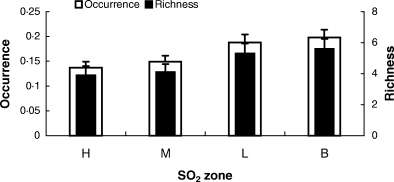

**Figure 1**

Mean (+ SE) site occurrence and species richness of species at high (H), medium (M), low (L) and background (B) SO<sub>2</sub> zones. A mean occurrence of 0·1 means that on average each species occupied 10% of sites. Only those species occurring at > 2 sites (*n* = 26) were considered for occurrence.

[figure not shown]

**Figure 2**

Occurrence (proportion of sites occupied) of common species at high (H), medium (M), low (L) and background (B) SO<sub>2</sub> zones.

Table 3. Results of GLM tests of the effects of habitat type and SO<sub>2</sub> zone on the occurrence of the eight most common species (those recorded from at least 15 sites). Data are *P*‐values, with significant values indicated in bold

|  | Habitat type | SO<sub>2</sub> zone |
| --- | --- | --- |
| *Rhytidoponera* sp. nr. *cornuta* | **0·02** | 0·08 |
| *Rhytidoponera* sp. nr *rufithorax* | 0·74 | 0·16 |
| *Iridomyrmex* sp. nr. *mayri* | **0·01** | 0·63 |
| *Camponotus* sp. A (*denticulatus* gp) | 0·41 | **0·001** |
| *Camponotus* *fieldae* | **0·05** | **0·02** |
| *Camponotus* sp. D (*novaehollandiae* gp) | **0·000** | **0·05** |
| *Camponotus* sp. F (*subnitidus* gp) | 0·56 | 0·15 |
| *Camponotus* sp. Q (*discors* gp) | 0·97 | 0·23 |

The functional group–zone interaction was not significant (deviance ratio = 1·51, d.f. = 12,396, *P* > 0·05), indicating that functional group composition was relatively uniform across SO<sub>2</sub> zones. There was a tendency for specialist predators to favour low levels of SO<sub>2</sub> (the nine records occurred exclusively in the low or background zones; Table 2), but their numbers were too low to influence the overall analysis. In contrast, the biogeographical group–zone interaction was highly significant (deviance ratio = 4·57, d.f. = 6,418, *P* < 0·001). The mean occurrence of widespread species was relatively constant, but the occurrence of Torresian species declined systematically in relation to SO<sub>2</sub>, and Eyrean taxa showed a curvilinear response (Fig. 3).

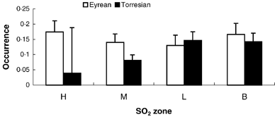

**Figure 3**

Mean (+ SE) occurrence (proportion of sites occupied) of eyrean and torresian biogeographical groups at high (H), medium (M), low (L) and background (B) SO<sub>2</sub> zones.

### SPECIES COMPOSITION

Multivariate ordination showed strong separation of habitats according to species composition, with rocky ridge and alluvial plain habitats at the two extremes, and rocky plains intermediate (Fig. 4). This was supported by a highly significant species–habitat interaction in GLM (deviance = 174·84, d.f. = 80, *P* < 0·001). Similarly, SO<sub>2</sub> zones were also clearly evident in ordination space (Fig. 4), and this was supported by a highly significant species–zone interaction in GLM (deviance = 222·18, d.f. = 120, *P* < 0·001).

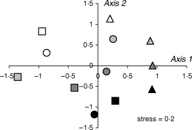

**Figure 4**

Multivariate ordination based on occurrence of ant species from rocky ridge (triangles), rocky plain (circles) and alluvial plain (squares) habitats, located in background (open symbols), low (lightly shaded), medium (heavily shaded) and high (closed) SO<sub>2</sub> zones.

## Discussion

### RELIABILITY OF SIMPLIFIED PROTOCOL

The intensive ant survey at Mt Isa, yielding 174 species, documented seven clear responses of ant communities to variation in habitat and SO<sub>2</sub> (Table 1). Our simplified ant assessment protocol utilized the ant bycatch from routine vertebrate pitfall traps, with analysis restricted to the occurrence of larger species. It recorded 41 species, and required less than 10% of the effort demanded by the intensive ant sampling programme. How well did it reproduce the seven results of the intensive ant survey?

#### Ant abundance declined with increasing SO<sub>*2*</sub>

Our simplified protocol only considered species presence/absence, so we used mean occurrence as a surrogate of abundance. Mean occurrence showed a significant decline with increasing SO<sub>2</sub>.

#### Species richness declined with increasing SO<sub>*2*</sub>

Our simplified protocol reproduced this pattern, but the variation was not quite statistically significant.

#### Species composition varied with SO<sub>*2*</sub>

Multivariate analysis of our results showed clear separation of SO<sub>2</sub> zones based on ant species composition, including distinguishing between low and background zones.

#### Several common species showed clear abundance patterns in relation to SO<sub>*2*</sub>

The species commonly recorded by our simplified protocol showed a wide range of responses to SO<sub>2</sub>. Only one species, *Camponotus* sp. A (*denticulatus* gp), was commonly recorded in our study as well as in the intensive survey, and in both cases abundance clearly increased with increasing SO<sub>2</sub>. None of our other common species was recorded frequently enough in the intensive survey to detect their responses to SO<sub>2</sub>.

#### Ant functional group composition showed relatively little change in relation to SO<sub>*2*</sub>

From the results of our simplified protocol, the lack of a significant functional group–zone interaction indicated that functional group profiles were relatively uniform across SO<sub>2</sub> zones.

#### Ant responses varied according to biogeographical affinity

As in the intensive survey, our results revealed that Eyrean and Torresian taxa showed systematic overall variation in relation to SO<sub>2</sub>, but that widespread taxa did not. In both cases there were marked declines in Torresian taxa with increasing SO<sub>2</sub>. The intensive survey showed marked increases in Eyrean taxa with increasing SO<sub>2</sub>, but this was only weakly evident in our data.

In summary, our simplified protocol reproduced virtually all the key findings of the intensive survey. This was despite some differences in sampling design. Moreover, the protocol not only detected rather obvious environmental variation, such as between major habitat types, and emission impacts in the immediate vicinity of the smelter, but was sensitive to the effects of low SO<sub>2</sub> levels up to 35 km away. Such effects on fauna were unable to be detected by intensive vertebrate survey.

Our simplified ant assessment protocol was highly effective at Mt Isa, but how widely applicable are our results to other regions? The reliability of our protocol elsewhere depends on the suitability of the environment for pitfall trapping, and the abundance and diversity of the resident ant fauna. Pitfall trapping is effective for sampling ants in relatively open environments (Andersen 1991; 1997c) but becomes less effective as the complexity of the ground layer increases, and is relatively ineffective in habitats with dense leaf litter (Agosti *et al*. 2000). Our protocol also relies on a diverse and abundant ant fauna. As such it is ideally suited for Australia, where open habitats predominate and the ant fauna is exceptionally diverse. We and our colleagues have used the protocol successfully to sample ants throughout inland Australia (Woinarski *et al.* 2002). It is likely to be similarly effective in arid lands and the seasonal tropics throughout the world. On the other hand, it would be less effective in cool–temperate zones, where ant diversity is relatively low and most of the abundant and speciose genera are relatively small sized (e.g. *Formica*, *Lasius* and *Leptothorax* throughout the Holarctic; Creighton 1950; Bolton 1995). In these regions, the body size threshold of 4 mm would have to be reduced in order to cover sufficient numbers of species.

### USING ANTS AS BIOINDICATORS

Many authors have discussed the ideal attributes of an indicator group for assessing ecological change, and ants routinely perform well against these criteria (Majer 1983; Greenslade & Greenslade 1984; Brown 1997). Many of the attributes directly address a taxon’s ability to reflect general ecological change, and relate to their abundance, diversity, functional importance and sensitivity to disturbance. Ants clearly meet these criteria, especially in Australia (Andersen 1990). However, it is also recognized that costs and logistic constraints are important variables in the design of monitoring programmes (Spellerberg 1991). Ants also perform relatively well in this context. For example, Brown (1997) scored 21 potential insect indicator taxa in the neotropics according to a variety of attributes relating primarily to their practicality of use, and ants rated equal highest, scoring 19 out of a possible 20 points. Nevertheless, ants still pose formidable challenges for workers who are inexperienced with insect surveys.

The simplified ant assessment protocol we have tested here overcomes many of these challenges. First, it is readily incorporated into routine wildlife surveys, such that ants can be reliably assessed without specifically sampling for them. Alternatively, if vertebrate trapping is not being conducted, it is simple to install pitfall traps specifically for ants, as this takes only a few minutes per trap. Secondly, by considering only a subset of species it greatly reduces laboratory time required for the processing and sorting of specimens. Most ant species are relatively small (< 4 mm), so most species were ignored by our protocol. Thirdly, large species are far easier to sort into morphospecies than are small species. Throughout the world, small‐sized taxa (such as the myrmicine genera *Pheidole*, *Crematogaster*, *Monomorium*, *Leptothorax* and *Strumigenys*) are typically the most demanding ants taxonomically, and require considerable experience for them to be reliably sorted to species level. Most large species can be successfully sorted with only limited experience, such that a focus on large species makes ants accessible to a wide range of users. Finally, these efficiencies mean that a greater number of sites can be surveyed. Despite taking only about 10% of the effort, in this study our protocol was able to sample 65 sites compared with 40 for the intensive survey.

Our sampling protocol has parallels with the concept of ‘taxonomic sufficiency’ (Ellis 1985), which addresses the level of taxonomic resolution at which samples are most efficiently sorted and analysed. Both approaches focus on the resolution required to satisfy the objectives of the monitoring or assessment programme, as opposed to what is required for a comprehensive description of the taxa under investigation. Given that they comprise a single taxonomic family, the question of taxonomic sufficiency for ants is one of genus‐level analysis. Analysis of ant community data at genus level can often reproduce species‐level patterns (Andersen 1997b; Pik, Oliver & Beattie 1999), but the reliability of genus as a surrogate for species in ants can vary widely between regions (Andersen 1997a). Our protocol has the advantages of species‐level precision, and achieves efficiency through ‘sampling sufficiency’.

### CONCLUSION

For 20 years scientists have been promoting the use of terrestrial invertebrates as bioindicators, but such use still largely remains a topic discussed by scientists rather than a practice embraced by land managers. In the scientific arena, attention has focused on identifying the most reliable indicator taxon. However, the actual use of invertebrates by land managers is not limited by scientific uncertainty over which taxon might give the most precise results. Rather, it is limited by general unfamiliarity and inexperience with dealing with insects. The truth is that a number of functionally important invertebrate groups can provide valuable information on ecological change associated with land use. We suggest that research directed at making these groups accessible to land managers deserves higher priority than does further assessment of the relative merits of different candidate taxa. Once invertebrate bioindicators become engrained in land‐management culture, then it would be appropriate to focus attention on what might be the ‘best’ indicator taxon.

The main finding of our study does not really concern the details of our simplified sampling protocol. Rather, it is the fact that comprehensive sampling was not required to reveal complex ant community responses to land use. Our study has shown that a relatively few taxonomically tractable ants can say a lot about the environment in which they occur, and considerably more than could traditional wildlife (vertebrate) surveys. This is not to decry the need for detailed studies of ants or other invertebrate groups as part of research into ecological responses to land use. However, the requirements of such research should not be confused with those of routine monitoring programmes, where the focus is not on the target groups *per se*, but on using them to provide information on the broader environment. The main issue in environmental monitoring is not whether or not samples are comprehensive, but whether they are reliable, and we have shown that simplified ant sampling can provide reliable results.

## Acknowledgements

We thank Brandon Bestelmeyer, Jonathan Majer, John Woinarski and Rochelle Lawson for their helpful comments on the draft manuscript. This is CSIRO’s Tropical Ecosystems Research Centre publication number 1170.

## Citing Literature

[figure not shown]

[Volume39, Issue1](https://besjournals.onlinelibrary.wiley.com/toc/13652664/2002/39/1)

February 2002

Pages 8-17

### Metrics

- Citations: 138

### Keywords

  - [environmental assessment](https://besjournals.onlinelibrary.wiley.com/action/doSearch?field1=Keyword&text1=environmental%20assessment)
  - [land‐use impacts](https://besjournals.onlinelibrary.wiley.com/action/doSearch?field1=Keyword&text1=land%E2%80%90use%20impacts)
  - monitoring
  - [sampling protocols](https://besjournals.onlinelibrary.wiley.com/action/doSearch?field1=Keyword&text1=sampling%20protocols)
  - [SO<sub>2</sub>](https://besjournals.onlinelibrary.wiley.com/action/doSearch?field1=Keyword&text1=SO2)

### Publication History

[Download PDF](https://besjournals.onlinelibrary.wiley.com/doi/pdf/10.1046/j.1365-2664.2002.00704.x)

back